# Normal Distribution

Day 19

Claire Kelling

Carleton College  
STAT 120 - Fall 2026

## Question of the Day

Are you watching a TV show right now or have you recently seen a good movie?

Please download the code for today’s class and pull up Statkey!

## Today’s Topics

Please download the code for today’s class and pull up Statkey!

Logistics:

- Reminder about office hours this week
- Questions about Quiz 3 on Friday or Final Project?
- Randomization Distribution on Statkey: sample stat

Topics covered today: (Sections 5.1-5.2)

- Finishing up Chapter 4
- Normal Distribution
- Central Limit Theorem

## Rest of Course

- We’ve covered the core ideas of intro stats:
  1. **EDA**: using pictures and numbers to make sense of data
  2. **Estimation**: estimating unknown parameters with confidence
  3. **Testing**: assessing hypotheses with p-values
- The rest of the course covers more types of inference methods
  - Instead of using computer simulations to generate bootstrap/randomization distributions, we will use probability models to do this

# Normal Distribution

## Bell Shaped Curves

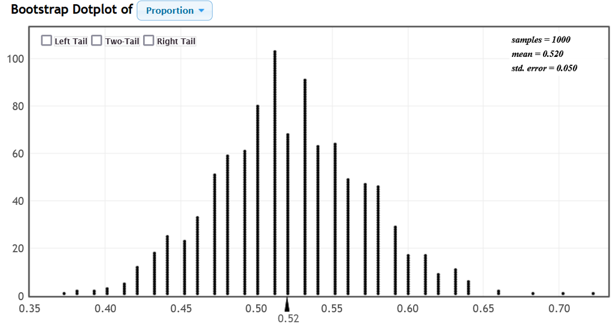

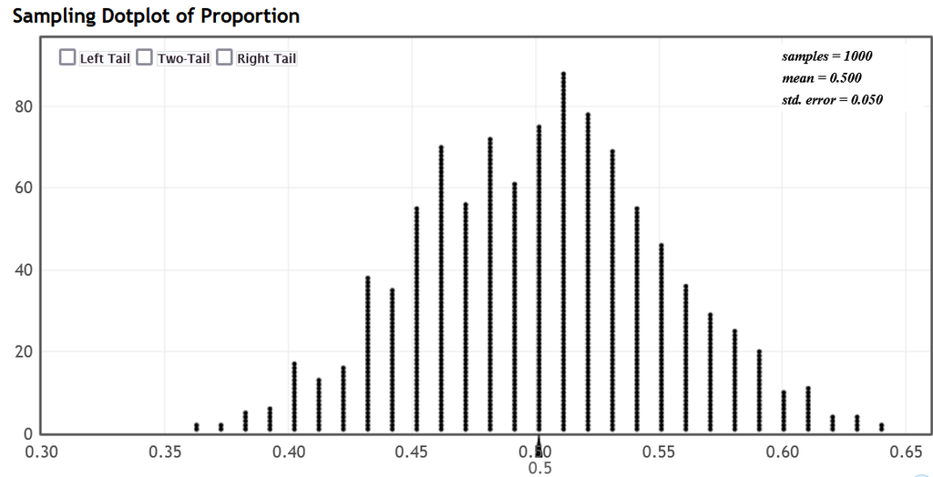

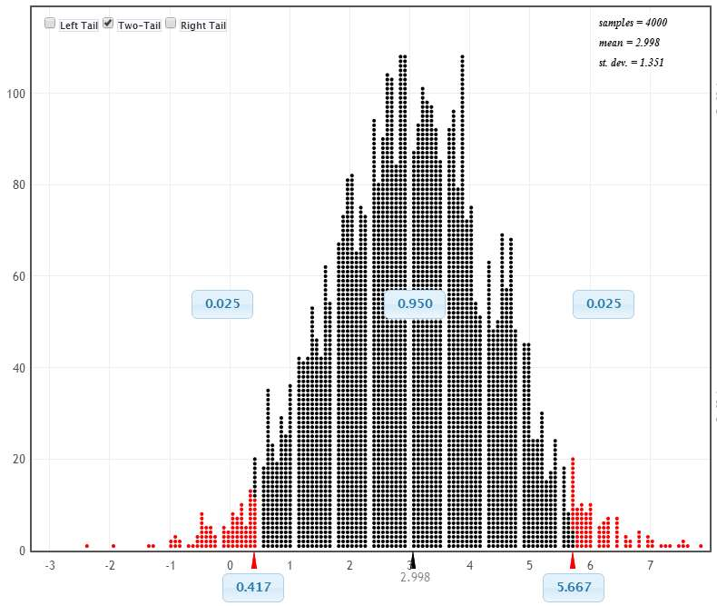

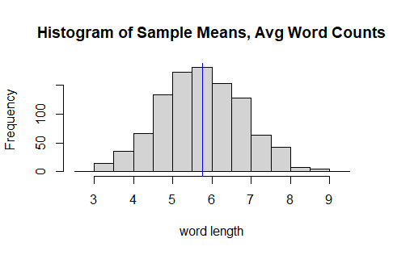

All of these symmetric bell-shaped curves are called **normal distributions.**

## Density Curve

**Definition**

A **density curve** is a theoretical model to describe a distribution.

Distribution for:

- Individual measurements in population (for a quantitative variable)
- Sampling distribution for a statistic

All density curves:

- Have an area under the curve of 1 (100%)
- Give proportions/percents of the data as **areas** under the curve

## Normal Distribution

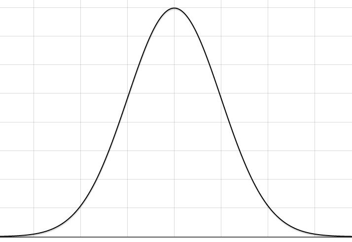

A **normal distribution** has a symmetric bellshaped density curve.

## The Normal Model

**Normal Model**

- The mean and SD determine how a normal density curve looks.
- The normal model **parameters** are
- $\mu$ = model mean (center)
- $\sigma$ = model standard deviation (variability)
- $X \sim N(\mu, \sigma)$

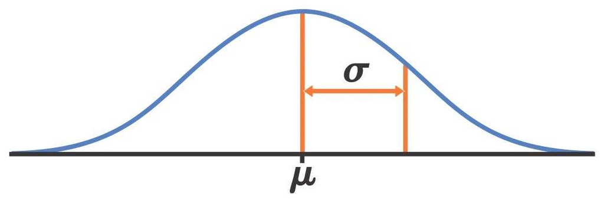

## Normal Distributions

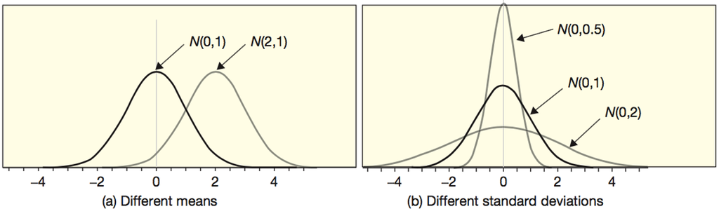

- Area under curve is **always** 1

## Example: Consider a Population

**SAT Scores**

- Verbal SAT $\sim N(580, 70)$

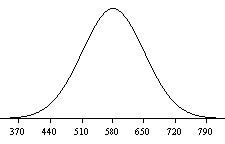

- What proportion of people score above 650?

## Example: Consider a Population

**SAT Scores**

- Verbal SAT $\sim N(580, 70)$

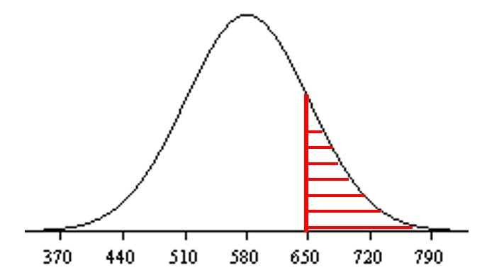

- What proportion of people score above 650?
- Area under the curve for scores 650 & higher.

## Area Under the Curve

How can we find areas under a normal density?

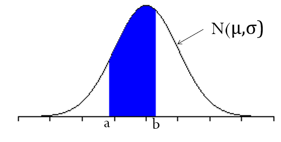

- $\text{Area} = \int_a^b \frac{1}{\sqrt{2\pi}\sigma} \exp(-\frac{(x-\mu)^2}{2\sigma^2})dx$

(Calculus!) - We can use technology to answer this question…

## Statkey- Verbal SAT population

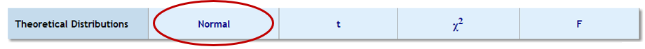

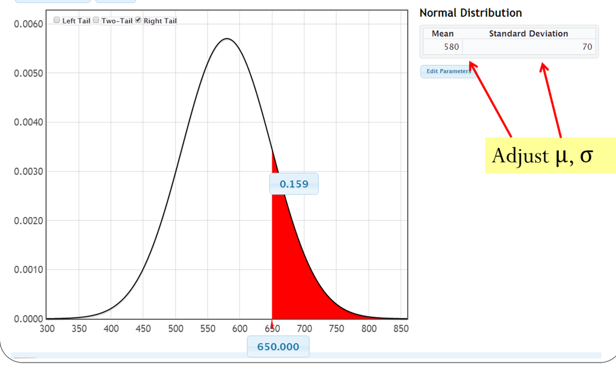

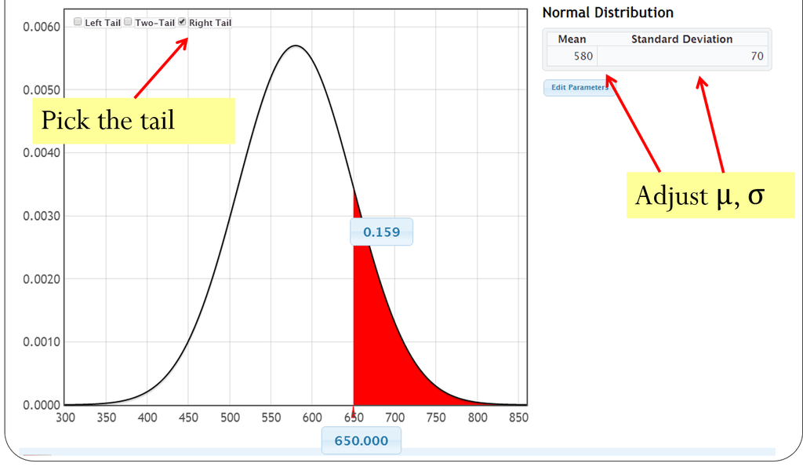

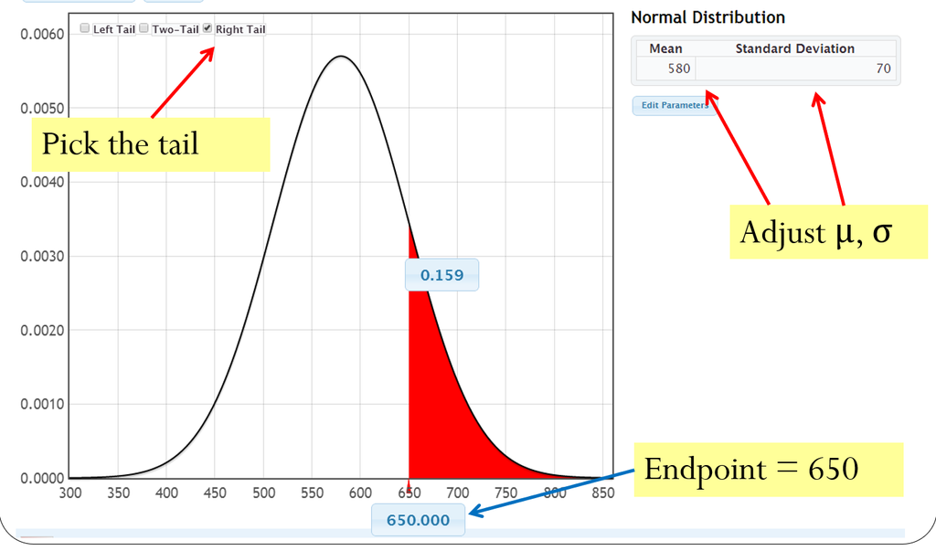

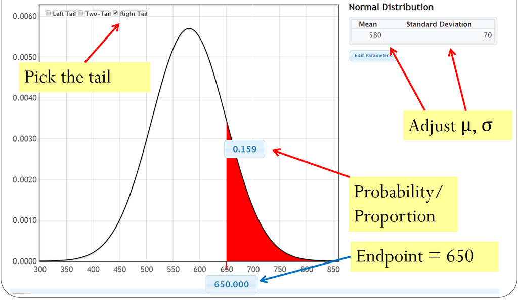

## Verbal SAT in R

- pnorm(x, mean, sd) gives the area **below x** under a normal curve with given mean and sd (**p** = proportion)
- What percent of the population had a score of 650 **or higher**?
- Let’s do it in R! **Example 1a.** Write your finding down too!

```r
# area below
pnorm(650, mean=580, sd=70)
```

```
[1] 0.8413447
```

```r
# area above
1-pnorm(650, mean=580, sd=70)
```

```
[1] 0.1586553
```

**Finding:**

About 16% of people in this population had a score of 650 or higher on the Verbal SAT.

## Percentiles of Normal Distribution

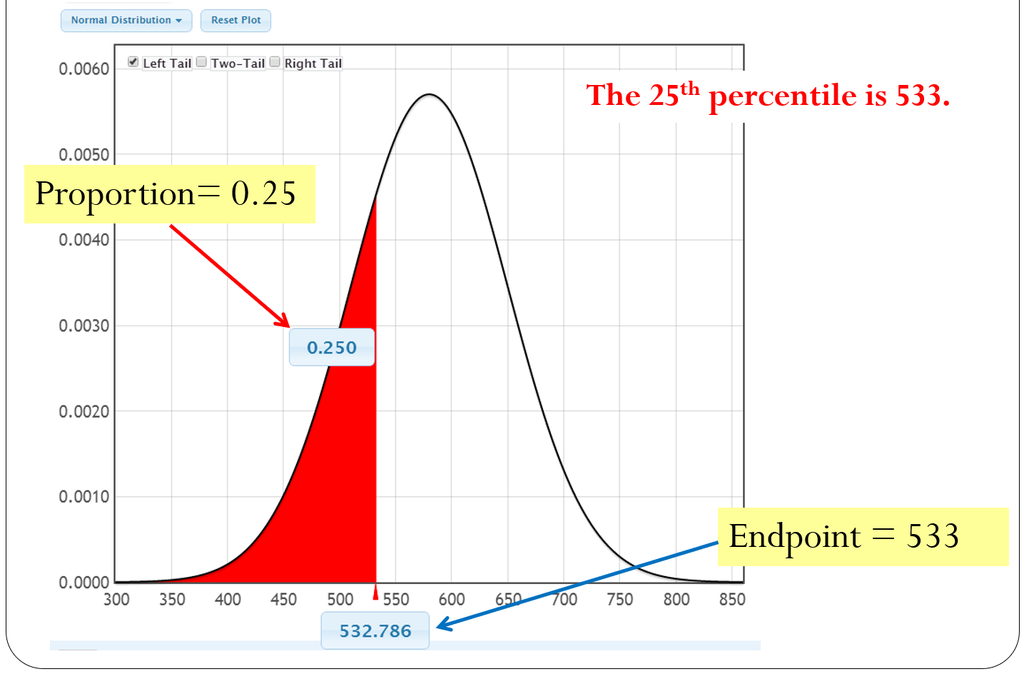

## Percentiles in R

- qnorm(p, mean, sd) gives the pth quantile (100(p)% percentile) under a normal curve with given mean and sd
- What score is the 25th percentile? Let’s do it in R! **Example 1b.** Write your finding down too!

```r
qnorm(.25, mean=580, sd=70)
```

```
[1] 532.7857
```

What is the interpretation of this for Verbal SAT scores?

- About 25% of people in the population score below 533 on the Verbal SAT.

## Finding Probabilities for $N(\mu,\sigma)$

- About what proportion should be within **one** standard deviation of the mean?

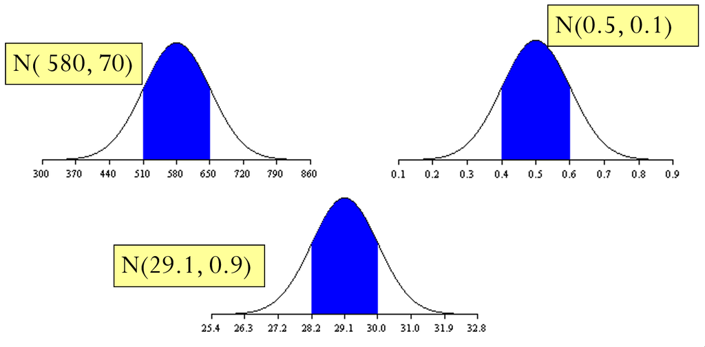

About 68%

**Big Idea for Normal Models**: All that really matters is the number of standard deviations from the mean.

## Returning to Z-scores

- For Normal models, all we need is a z-score (look familiar?)

**Standard Normal**

- $\mu = 0, \sigma = 1$
- $Z \sim N(0,1)$

where

$$Z = \frac{x - \mu}{\sigma}$$

## Connecting any Normal Dist to Standard Normal

Area below x = Area below z

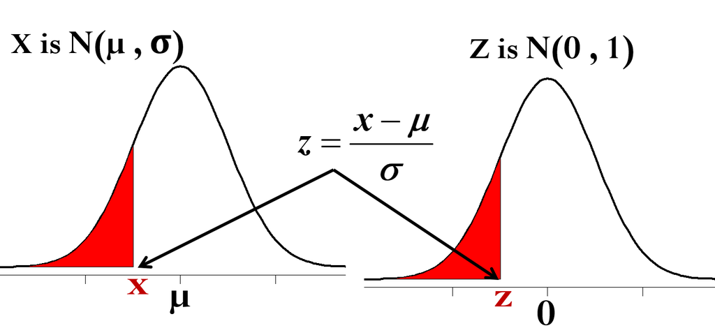

## Verbal SAT Example

What is the percent of people with scores above 650?

1. Calculate Z-score for 650 based on mean (580) and standard deviation (70)

   $$Z = \frac{650-580}{70} = 1$$
2. Score of 650 is one standard deviation above the average
3. Can then use standard normal distribution for percentiles
4. About 16% of people will get a score of at least 650.

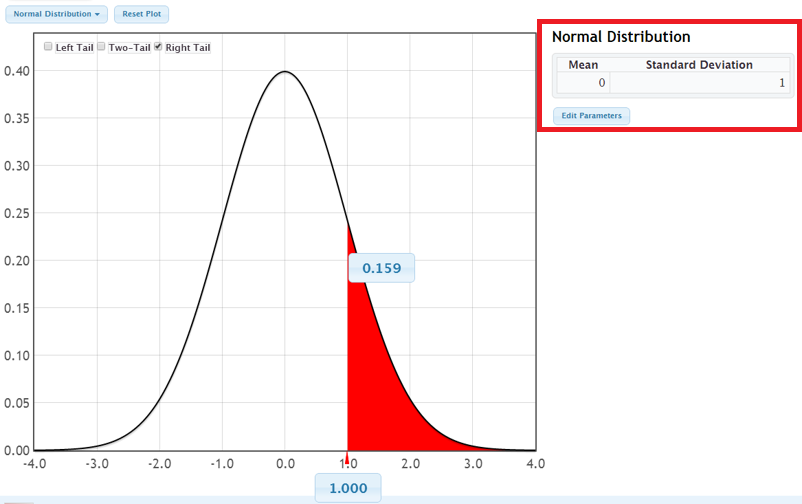

## Verbal SAT Example

Find the 25th percentile for the Verbal SAT score.

- 25th Percentile for $Z \sim N(0,1)$ is -0.674.
- (All 25th percentiles are 0.674 SDs below average.)
- Can calculate 25th percentile based on Z-score

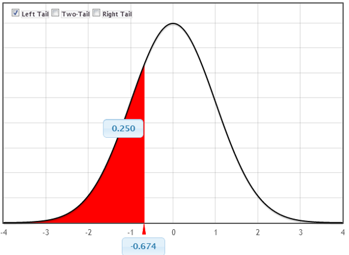

$$Z = \frac{x-\mu}{\sigma}$$

$$-0.674 = \frac{x - 580}{70}$$

$$x = (-0.674 \times 70) + 580 = 533$$

25th percentile is an SAT score of 533.

## Why Normal Distribution?

- When have we already been using normal models?
  - Bootstrap distributions - get confidence intervals if a bootstrap distribution is roughly bell-shaped.
  - Randomization distributions - many of these are bell-shaped.
- Normal models play a huge role in statistical inference.
- **If we know the (bootstrap/randomization) standard error*** then we can just use a normal model rather than a resampling model (which requires more computational effort).
- * we will address the SE issue later this week (ch.6)!

# Central Limit Theorem

## Central Limit Theorem

**Definition**

**Central Limit Theorem:** For random samples with a *sufficiently large sample size*, the distribution of sample statistics for a **mean** or a **proportion** (or a difference) is normally distributed

## Central Limit Theorem

**The Catch**

What does “sufficiently large sample size” mean?

- The more skewed the original distribution of data/population is, the larger $n$ has to be for the CLT to work
- For quantitative variables that are not very skewed, n $\geq$ 30 is usually sufficient
- For categorical variables, counts of at least 10 within each category is usually sufficient

## Normal Model and Hypothesis Tests

**Hypothesis Tests**

- **Suppose**: randomization distribution is bell-shaped
- **Center**: hypothesized null parameter value
- **Spread**: the standard error given in the randomization graph (or by formula)

**P-value and Normal Model**

- The p-value is computed from the normal model the “usual” way - the chance of being as extreme, or more extreme, than the observed statistic.

## Sleep vs Caffeine Randomization Dist

$$H_0: \mu_S - \mu_c = 0 \text{ vs } H_a: \mu_S - \mu_C \neq 0$$

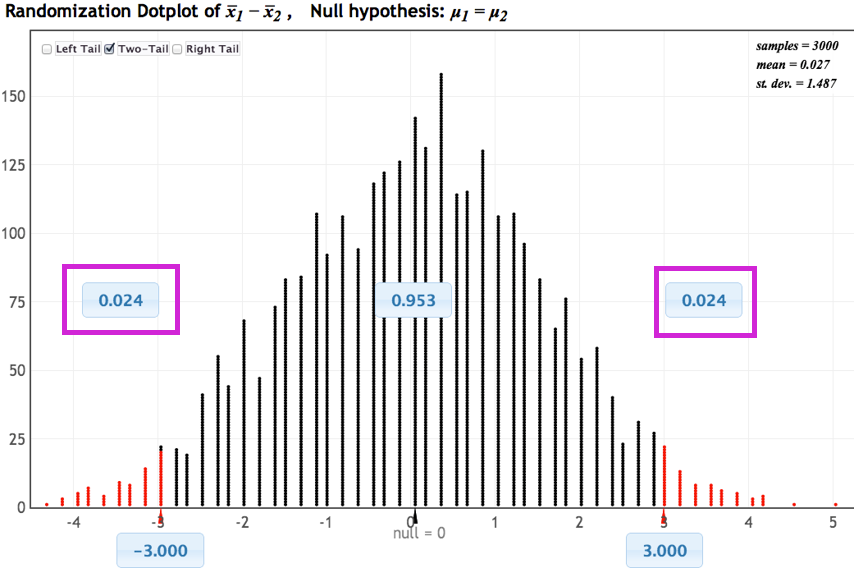

Typical Procedure:

- $\bar{X}_S - \bar{X}_C = 3$
- p-value = 2 $\times$ 0.024 = 0.048

## Sleep vs Caffeine

$$H_0: \mu_S - \mu_c = 0 \text{ vs } H_a: \mu_S - \mu_C \neq 0$$

- The observed difference is 3 words. ($\bar{X}_S - \bar{X}_C = 3$)
- The randomization dist is approximately N(0, 1.5).
- **SO** we can calculate and find that the observed difference is 2 SEs above the null difference of 0:

$$Z = \frac{\text{sample stat} - \text{null param value}}{SE} = \frac{3-0}{1.5} = 2$$

- The p-value is the area above +3 and below -3 on the N(0, 1.5) model.
- Equivalently, the p-value is the chance of getting a mean difference more than 2 SEs away from the hypothesized mean difference of 0 (looking to the N(0,1) distribution).

## Sleep vs Caffeine

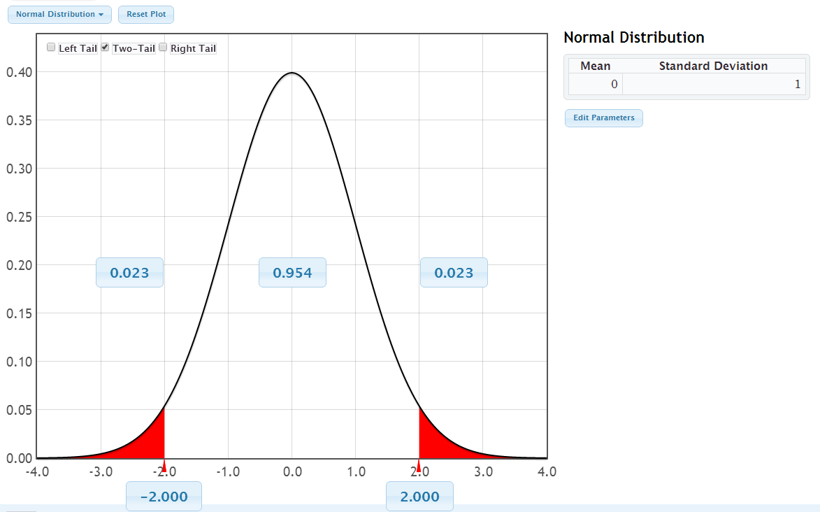

- Using N(0,1) Model, the p-value is about 2(0.023) = 4.6% using the standardized test statistic value (which is 2)

```r
2*pnorm(-2)
```

```
[1] 0.04550026
```

## Standardized Test Statistic

**Definition**

The standardized test statistic is the number of standard errors a statistic is from the null:

$$Z = \frac{\text{sample statistic} - \text{null parameter}}{SE}$$

- Calculating the number of standard errors a statistic is from the null value allows us to **assess extremity on a common scale (just like the p-value does)**.

## Normal Model and Confidence Intervals

Confidence Intervals:

- **Suppose**: bootstrap distribution is bell-shaped.
- **Center**: sample statistic
- **Spread**: the standard error given in the bootstrap graph (or by formula)

**95% CI Calculation**

$$\text{statistic} \pm 2(SE)$$

Why 2 SE’s?

- 95% of all sample means fall within 2 SE’s of the pop mean*
- The value 2 is a z-score from a N(0,1) distribution!
- * well, actually the precise z-score under a normal model is z=1.96 instead of 2

## Confidence Interval using N(0,1)

**CI with Std Normal**

If a statistic is normally distributed, we find a confidence interval for the parameter using

$$\text{statistic} \pm z^* \times SE$$

- where the area between $-z^*$ and $+z^*$ in the standard normal distribution is the desired level of confidence.

## N(0,1) Model

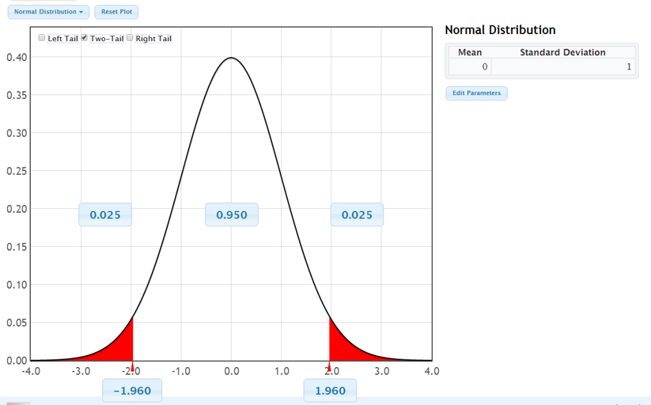

- 95% of all values fall within 1.96 SE’s of the mean

```r
qnorm(0.975)
```

```
[1] 1.959964
```

- What if we wanted a 90% CI? What z-score should we use to get the margin of error?

## Other Levels of Confidence

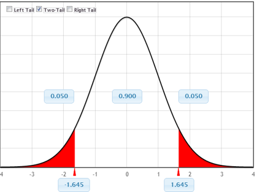

90% Confidence:

$z^*$ = 1.645

```r
qnorm(0.95)
```

```
[1] 1.644854
```

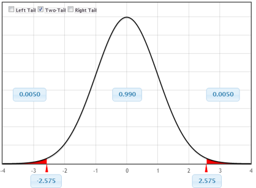

99% Confidence:

$z^*$ = 2.576

```r
qnorm(0.995)
```

```
[1] 2.575829
```

## Example: Global Warming?

What percent of Americans believe in global warming?

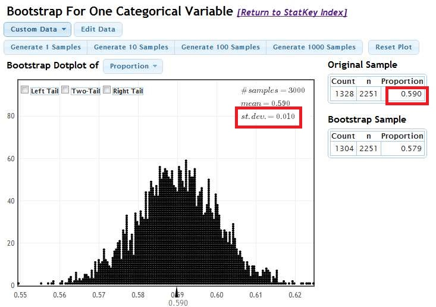

- 95% CI: $0.59 \pm 1.96(0.01) = (0.570, 0.610)$
- We are 95% sure that the true percentage of all Americans that believe there is solid evidence of global warming is between 57.0% and 61.0%
- 90% CI: $0.59 \pm$ 1.645$(0.01) = (0.574, 0.606)$
- 99% CI: $0.59 \pm$ 2.576$(0.01) = (0.564, 0.616)$

## Comparing to Bootstrap Percentile Method

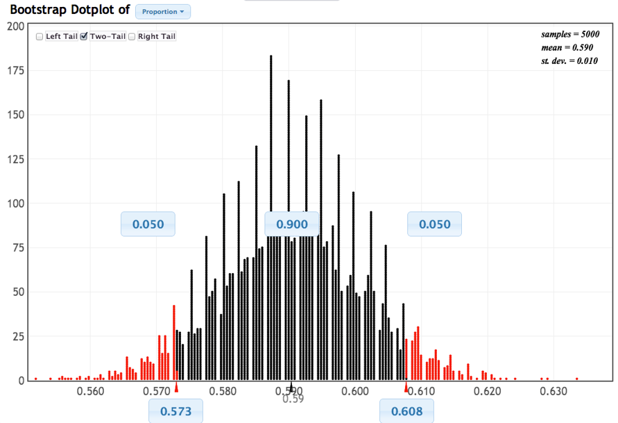

90% Confidence Interval:

- **Normal curve method**: $0.59 \pm$ $1.645(0.01) = (0.574, 0.606)$
- **Bootstrap Percentile Method:** (0.573, 0.608)

## Summary

- The **Normal distribution** and **Central Limit Theorem** can help us create confidence intervals and conduct hypothesis tests without the use of randomization and permutation distributions
- CI: $\text{statistic} \pm z^* \times SE$
- Hypothesis Testing: Find a p-value based on N(null param, $SE_{\text{randomization}}$) and potential conversion to $N(0,1)$
- **Problem:** We need to know the standard error of these distributions!

## Next Class

How can we compute the SE **without** doing thousands of simulations?